# Math 490 HW #4

Maxwell Levin

January 31, 2018

## Question 1.

#### Let random variable U be uniformly distributed over the interval [a, b]. Find $\small{E(U^2)}$ and $\small{Var(U^2)}$.

Since $\small{U}$ is a continuous random uniform distribution, we calculate $\small{E(U^2)}$ using the equation

$$E(U^2) = \int_a^bU^2f(U) dU,$$
$$E(U^2) = \frac{1}{b-a}\int_a^b U^2 dU,$$
$$E(U^2) = \frac{a^2 + ab + b^2}{3}.$$

We now calculate the variance of $\small{U^2}$:

$$Var(U^2) = E(U^4) - E(U^2),$$
$$Var(U^2) = \frac{b^5 - a^5}{5(b-a)} - \left(\frac{b^3-a^3}{3(b-a)}\right)^2.$$

## Question 2.

#### Consider sampling n = 4 random numbers $\small{U_1, U_2, U_3, U_4}$ from the Uniform[0,1] distribution, and let

$$\overline{V_4} = \frac{U_1^2 + U_2^2 + U_3^2 + U_4^2}{4}.$$

#### a. What are the mean and standard deviation of $\small\overline{V_4}$?

We calculate the mean:

$$E(\overline{V_4}) = E\left(\frac{U_1^2 + U_2^2 + U_3^2 + U_4^2}{4}\right),$$
$$E(\overline{V_4}) = E\left(\frac{1}{4}E(U_1^2) + \frac{1}{4}E(U_2^2) + \frac{1}{4}E(U_3^2) + \frac{1}{4}E(U_4^2)\right),$$
$$E(\overline{V_4}) = E(U^2).$$

Thus we can use our result from question 1 with $\small{a = 0,}$ $\small{b = 1}$ to get

$$E(\overline{V_4}) = \frac{1}{3}.$$

To calculate variance we use

$$Var(\overline{V_4}) = Var\left(\frac{U_1^2 + U_2^2 + U_3^2 + U_4^2}{4}\right),$$
$$Var(\overline{V_4}) = \left(\frac{1}{4}\right)^2Var(U_1^2) + \left(\frac{1}{4}\right)^2Var(U_2^2) + \left(\frac{1}{4}\right)^2Var(U_3^2) + \left(\frac{1}{4}\right)^2Var(U_4^2),$$
$$Var(\overline{V_4}) = \frac{1}{4}Var(U^2).$$

Thus we can again apply our results from question 1 to achieve

$$Var(\overline{V_4}) = \frac{1}{45} \approx 0.0222,$$
$$SD(\overline{V_4}) = \sqrt{Var(\overline{V_4})} \approx 0.1491$$

#### b. Use R to simulate 1024 sample means $\small\overline{V_4}$, make a histogram, and report the mean (center) and standard deviation (spread) of the simulated sample means.

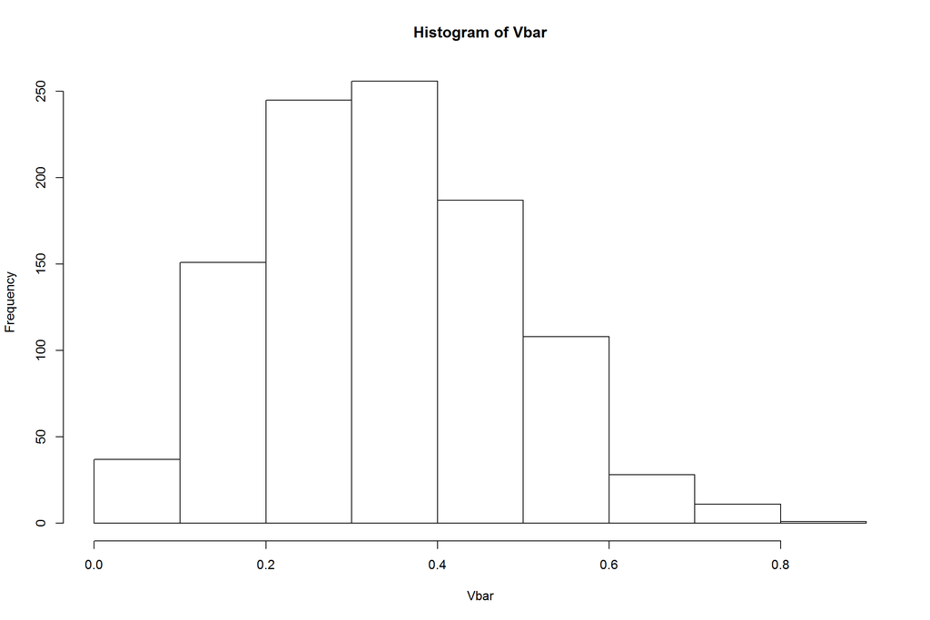

```r
u1 = runif(1024, 0, 1)
u2 = runif(1024, 0, 1)
u3 = runif(1024, 0, 1)
u4 = runif(1024, 0, 1)

Vbar = (u1^2 + u2^2 + u3^2 + u4^2) / 4

hist(Vbar)
```

The Mean is

```
[1] 0.3388733
```

The Standard Deviation is

```
[1] 0.1443659
```

#### c. Use a normal probability plot to access the normality of the 1024 sample means simulated in part b.

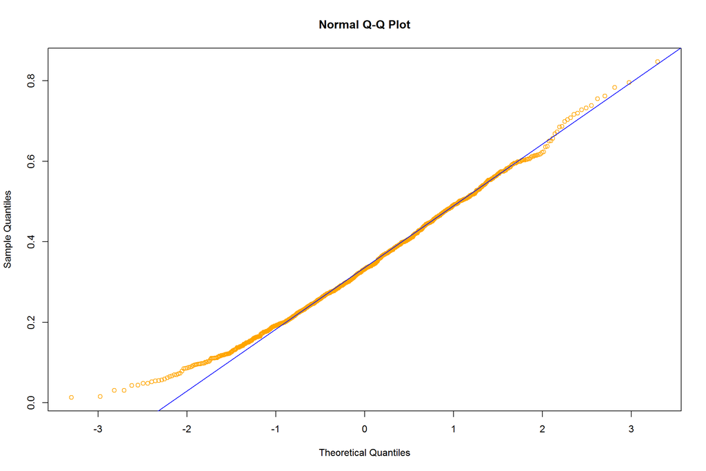

#### d. Use the Shapiro-Wilk test to assess the normality of the 1024 sample means simulated in part b.

```
    Shapiro-Wilk normality test

data:  Vbar
W = 0.99128, p-value = 9.373e-06
```

## Question 3.

#### Consider sampling n = 25 random numbers $\small{U_1, U_2, \dots, U_{25}}$ from the Uniform[0,1] distribution, and let

$$\overline{V_{25}} = \frac{U_1^2 + U_2^2 + \dots + U_{25}^2}{25}.$$

#### a. What are the mean and standard deviation of $\small\overline{V_4}$?

We calculate the mean:

$$E(\overline{V_{25}}) = E\left(\frac{U_1^2 + U_2^2 + \dots + U_{25}^2}{25}\right),$$
$$E(\overline{V_{25}}) = E\left(\frac{1}{25}E(U_1^2) + \frac{1}{25}E(U_2^2) + \dots + \frac{1}{25}E(U_{25}^2)\right),$$
$$E(\overline{V_{25}}) = E(U^2).$$

Thus for an interval from 0 to 1 our mean is

$$E(\overline{V_{25}}) = \frac{1}{3}.$$

We calculate the variance:

$$Var(\overline{V_{25}}) = Var\left(\frac{U_1^2 + U_2^2 + \dots + U_{25}^2}{25}\right)$$
$$Var(\overline{V_{25}}) = \left(\frac{1}{25}\right)^2Var(U_1^2) + \left(\frac{1}{25}\right)^2Var(U_2^2) + \dots +
\left(\frac{1}{25}\right)^2Var(U_{25}^2)$$
$$Var(\overline{V_{25}}) = \frac{1}{25}Var(U^2).$$

We can apply our results from question 2 to get

$$Var(\overline{V_{25}}) = \frac{4}{1125} \approx 0.0036.$$

That is, the standard deviation of our sample means when n = 25 is

$$SD(\overline{V_{25}}) = \sqrt{Var(\overline{V_{25}})} \approx 0.0596.$$

#### b. Use R to simulate 1024 sample means $\small\overline{V_{25}}$, make a histogram, and report the mean (center) and standard deviation (spread) of the simulated sample means.

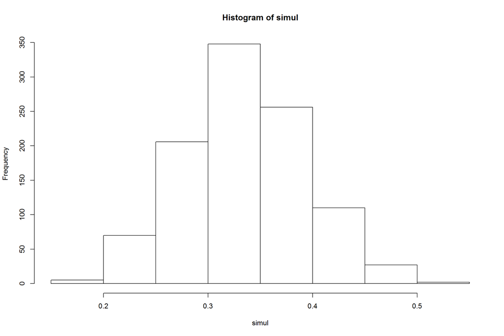

```r
clt = function(sam, rep) {
  obs = NULL
  for (i in 1:rep) {
    v = runif(sam, 0, 1)^2
    Vbar = mean(v)
    obs = c(obs, Vbar)
  }
  obs;
}

simul = clt(25, 1024)

hist(simul)
```

The mean is

```
[1] 0.3338086
```

The standard deviation is

```
[1] 0.05811372
```

#### c. Use a normal probability plot to access the normality of the 1024 sample means simulated in part b.

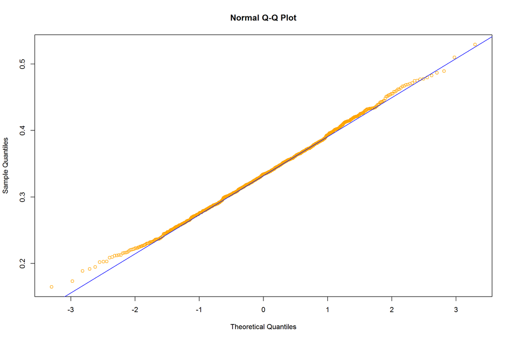

Our normal probability plot suggests that our simulation of sample means is pretty close to a normal distribution.

#### d. Use the Shapiro-Wilk test to assess the normality of the 1024 sample means simulated in part b.

```
    Shapiro-Wilk normality test

data:  simul
W = 0.99812, p-value = 0.3158
```